# Tim Ryko Analysis

2022-05-22

# Preparation

- Clear workspace
- Be sure that correct project is opened
- Install necessary packages
- Load packages

```r
library(tidyverse)
library(brms)
options(mc.cores = parallel::detectCores()) #sets the system to use multiple cores simultaneously while fitting models

library(patchwork)
library(ggdag)
library(dagitty)
library(simglm)

library(GGally)
```

# Get the data and explore it

```r
df = read_csv2('meie.csv')
```

```
## ℹ Using "','" as decimal and "'.'" as grouping mark. Use `read_delim()` for more control.
```

```r
df
```

```
## # A tibble: 67 × 7
##    local journal                       cites    IF  year n_auth foreign_collabo…
##    <chr> <chr>                         <dbl> <dbl> <dbl>  <dbl> <chr>
##  1 no    pnas                             56   112  2022     16 yes
##  2 no    viruses                           2   504  2021     28 yes
##  3 yes   antimicrobial agents chemoth…     0    52  2021      5 yes
##  4 yes   J investigative dermatology       0    85  2021      9 no
##  5 no    viruses                           2   504  2021     10 yes
##  6 no    mol cell                          3    18  2021     17 yes
##  7 no    viruses                           1   504  2021      8 yes
##  8 no    pnas                             13   112  2021      7 yes
##  9 yes   frontiers microbiol               2    56  2021      9 no
## 10 no    mol cell                         13    18  2021     10 yes
## # … with 57 more rows
```

The columns are as follows:

1. local (yes/no) - wether the last author of the paper is from this institute.
2. journal - name of the journal
3. cites - the number of citation this paper has collected over its lifetime
4. IF - journal impact factor (the average number of citations per paper in this journal within 2 years from publication)
5. year - the year of publication
6. n_auth - the number of authors on this paper
7. foreign_collaboration - whether any of the authors are from outside Estonia

Let’s check how much papers do we have in each of the journals:

```r
df %>%
  group_by(journal) %>%
  summarise(papers = length(journal)) %>%
  arrange(desc(papers))
```

```
## # A tibble: 35 × 2
##    journal                           papers
##    <chr>                              <int>
##  1 sci reports                           11
##  2 viruses                                8
##  3 pnas                                   6
##  4 antimicrobial agents chemotherapy      3
##  5 mol cell                               3
##  6 biochimie                              2
##  7 frontiers microbiol                    2
##  8 JMB                                    2
##  9 MBIO                                   2
## 10 NAR                                    2
## # … with 25 more rows
```

Not so much… Unfortunately, we have too many journals and too few publications in each of the journals to compare the data for different journals. We can safely delete it:

```r
df = df %>% select(-journal)
df
```

```
## # A tibble: 67 × 6
##    local cites    IF  year n_auth foreign_collaboration
##    <chr> <dbl> <dbl> <dbl>  <dbl> <chr>
##  1 no       56   112  2022     16 yes
##  2 no        2   504  2021     28 yes
##  3 yes       0    52  2021      5 yes
##  4 yes       0    85  2021      9 no
##  5 no        2   504  2021     10 yes
##  6 no        3    18  2021     17 yes
##  7 no        1   504  2021      8 yes
##  8 no       13   112  2021      7 yes
##  9 yes       2    56  2021      9 no
## 10 no       13    18  2021     10 yes
## # … with 57 more rows
```

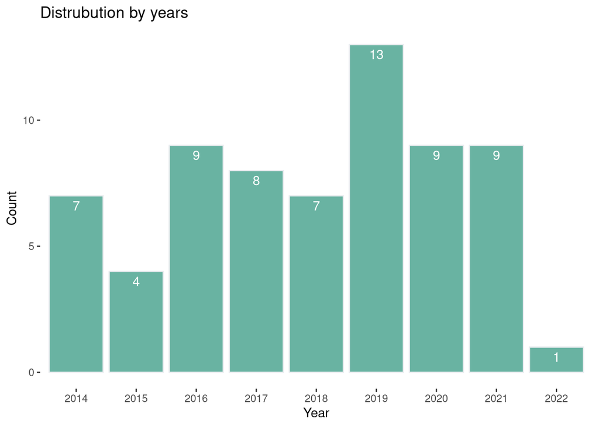

```r
df %>%
  ggplot(aes(factor(year))) +

    geom_bar(fill='#69b3a2', color='#e9ecef') +
    geom_text(aes(label = ..count..), stat = "count", vjust = 1.5, colour = "white") +

    ggtitle('Distrubution by years') +
    labs(x = 'Year', y='Count') +

    theme_bw() +
    theme(axis.line = element_blank(),
      panel.grid.major = element_blank(),
      panel.grid.minor = element_blank(),
      panel.border = element_blank(),
      panel.background = element_blank())
```

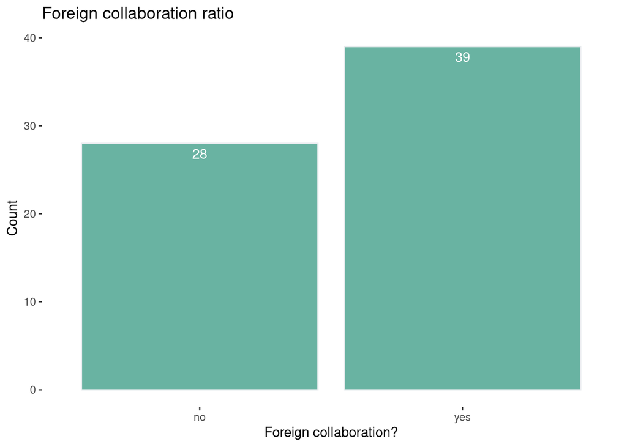

```r
df %>%
  ggplot(aes(factor(foreign_collaboration))) +

    geom_bar(fill='#69b3a2', color='#e9ecef') +
    geom_text(aes(label = ..count..), stat = "count", vjust = 1.5, colour = "white") +

    ggtitle('Foreign collaboration ratio') +
    labs(x = 'Foreign collaboration?', y='Count') +

    theme_bw() +
    theme(axis.line = element_blank(),
      panel.grid.major = element_blank(),
      panel.grid.minor = element_blank(),
      panel.border = element_blank(),
      panel.background = element_blank())
```

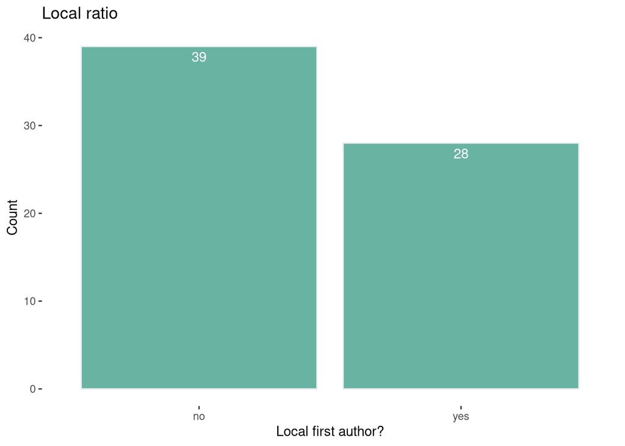

```r
df %>%
  ggplot(aes(factor(local))) +

    geom_bar(fill='#69b3a2', color='#e9ecef') +
    geom_text(aes(label = ..count..), stat = "count", vjust = 1.5, colour = "white") +

    ggtitle('Local ratio') +
    labs(x = 'Local first author?', y='Count') +

    theme_bw() +
    theme(axis.line = element_blank(),
      panel.grid.major = element_blank(),
      panel.grid.minor = element_blank(),
      panel.border = element_blank(),
      panel.background = element_blank())
```

# Questions to ask from this data

Let’s start with simple distributions and correlations analysis without any models:

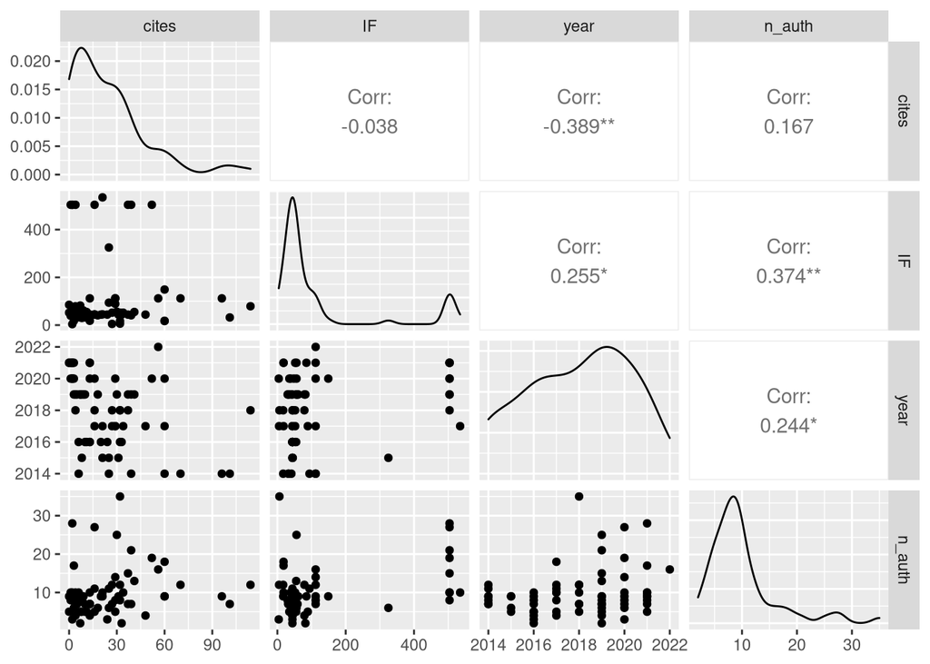

```r
df %>%
  select(-local, -foreign_collaboration) %>%
    ggpairs()
```

It looks like there are no strong or even moderate correlations. But what if we will divide our data by categories?

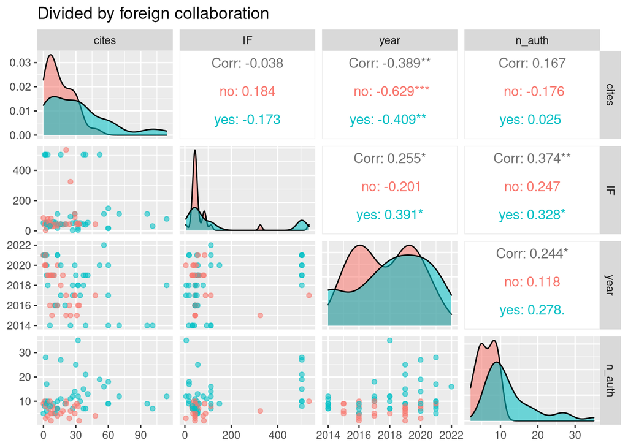

```r
df %>%
  select(-local) %>%
    ggpairs(
      aes(color = foreign_collaboration, alpha = 0.5),
      columns=1:4
    ) +
  ggtitle('Divided by foreign collaboration')
```

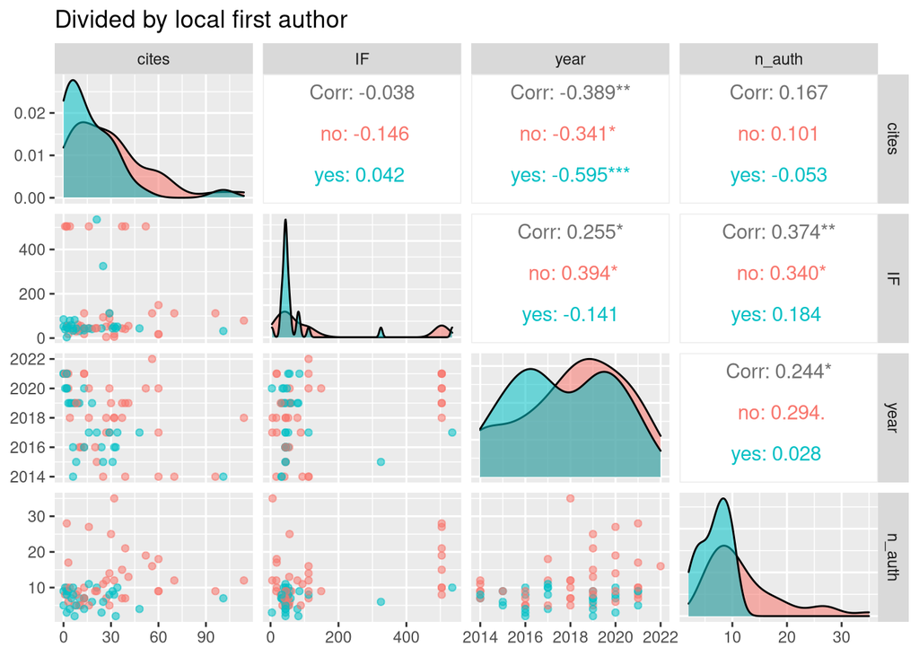

```r
df %>%
  select(-foreign_collaboration) %>%
    ggpairs(
      aes(color = local, alpha = 0.5),
      columns=2:5
    ) +
  ggtitle('Divided by local first author')
```

My proposal is that we have negative correlation between the year and the cites (it’s seen even more clearly, when we take into account foreign collaboration and local categories). We will try to confirm it by modelling.

Also, it seems to me quite logical, that IF should be correlated with the cites. However, we don’t observe it in our data. Probably, we will be able to identify this correlation by making adjustments for various factors in the models.

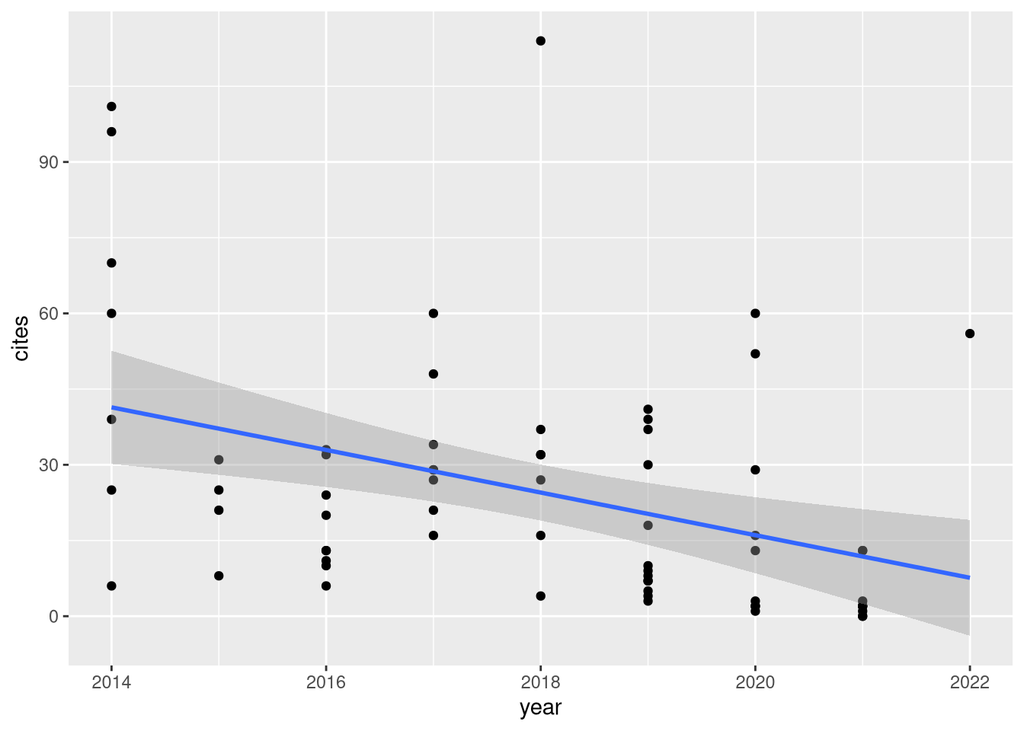

```r
df %>%
  ggplot(aes(year, cites)) +
  geom_point() +
  geom_smooth(method = 'lm')
```

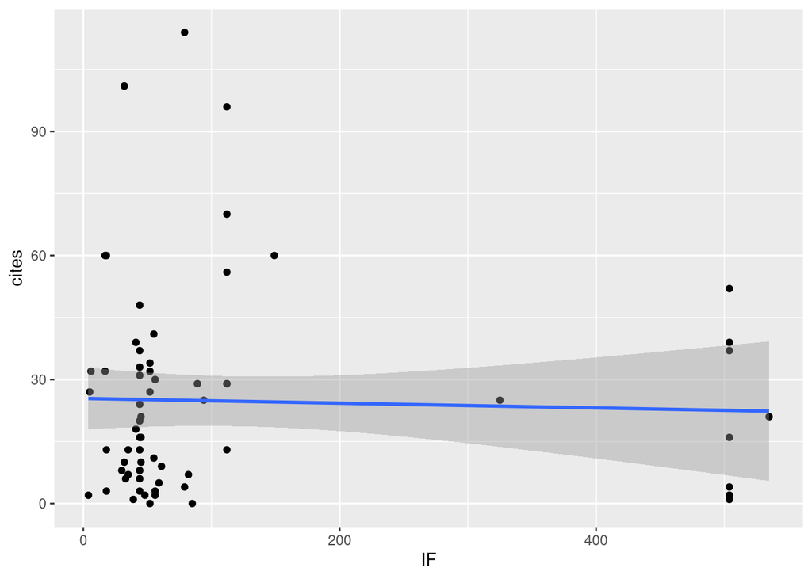

```r
df %>%
  ggplot(aes(IF, cites)) +
  geom_point() +
  geom_smooth(method = 'lm')
```

So, here are the questions we are going to investigate: 1) Correlation of the year and cites (negative expected) 2) The effect of IF on cites (positive expected)

# Models

## Basic models

Let’s start with simple models.

#### Fit the models for question 1 (year)

```r
simple_year_gm = brm(
  formula = cites ~ year,
  data = df,
  family = gaussian(),
  file = 'simple_year_gm'
)
```

```r
simple_year_hgm = brm(
  formula = cites ~ year,
  data = df,
  family = hurdle_gamma(),
  file = 'simple_year_hgm'
)
```

#### Compare the models for question 1 (year)

```r
l1 = loo(simple_year_gm)
l2 = loo(simple_year_hgm)
loo_compare(l1, l2)
```

```
##                 elpd_diff se_diff
## simple_year_hgm   0.0       0.0
## simple_year_gm  -23.1       6.9
```

#### Fit the models for question 2 (IF)

```r
simple_if_gm = brm(
  formula = cites ~ IF,
  data = df,
  family = gaussian(),
  file = 'simple_if_gm'
)
```

```r
simple_if_hgm = brm(
  formula = cites ~ IF,
  data = df,
  family = hurdle_gamma(),
  # More iterations, because Tail Effective Samples Size (ESS) is too low
  iter = 4000,
  file = 'simple_if_hgm'
)
```

#### Compare the models for question 2 (IF)

```r
l1 = loo(simple_if_gm)
l2 = loo(simple_if_hgm)
loo_compare(l1, l2)
```

```
##               elpd_diff se_diff
## simple_if_hgm   0.0       0.0
## simple_if_gm  -24.4       6.2
```

#### Plotting conditional effects

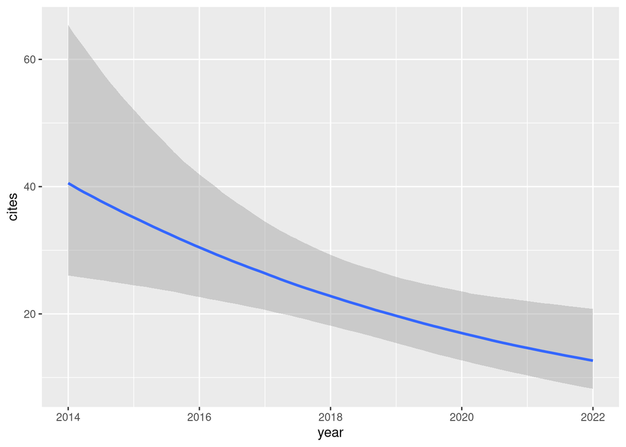

```r
simple_year_hgm %>% conditional_effects(effects = 'year')
```

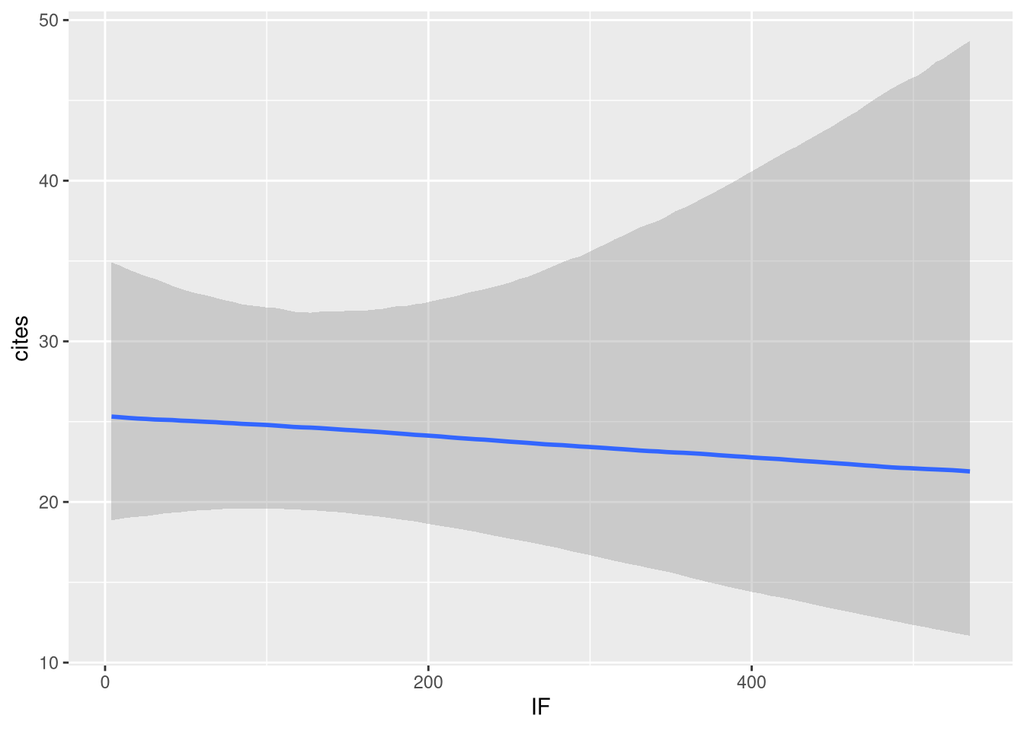

```r
simple_if_hgm %>% conditional_effects(effects = 'IF')
```

#### Model summaries

```r
simple_year_hgm
```

```
##  Family: hurdle_gamma
##   Links: mu = log; shape = identity; hu = identity
## Formula: cites ~ year
##    Data: df (Number of observations: 67)
##   Draws: 4 chains, each with iter = 2000; warmup = 1000; thin = 1;
##          total post-warmup draws = 4000
##
## Population-Level Effects:
##           Estimate Est.Error l-95% CI u-95% CI Rhat Bulk_ESS Tail_ESS
## Intercept   296.70    102.19    92.65   499.27 1.00     3796     2376
## year         -0.15      0.05    -0.25    -0.04 1.00     3796     2376
##
## Family Specific Parameters:
##       Estimate Est.Error l-95% CI u-95% CI Rhat Bulk_ESS Tail_ESS
## shape     1.17      0.18     0.84     1.55 1.00     4405     2939
## hu        0.04      0.02     0.01     0.11 1.00     4526     2530
##
## Draws were sampled using sampling(NUTS). For each parameter, Bulk_ESS
## and Tail_ESS are effective sample size measures, and Rhat is the potential
## scale reduction factor on split chains (at convergence, Rhat = 1).
```

```r
simple_if_hgm
```

```
##  Family: hurdle_gamma
##   Links: mu = log; shape = identity; hu = identity
## Formula: cites ~ IF
##    Data: df (Number of observations: 67)
##   Draws: 4 chains, each with iter = 4000; warmup = 2000; thin = 1;
##          total post-warmup draws = 8000
##
## Population-Level Effects:
##           Estimate Est.Error l-95% CI u-95% CI Rhat Bulk_ESS Tail_ESS
## Intercept     3.28      0.16     2.98     3.59 1.00     7116     5780
## IF           -0.00      0.00    -0.00     0.00 1.00     9947     5293
##
## Family Specific Parameters:
##       Estimate Est.Error l-95% CI u-95% CI Rhat Bulk_ESS Tail_ESS
## shape     1.06      0.17     0.77     1.42 1.00     4979     4463
## hu        0.04      0.02     0.01     0.10 1.00     4638     3337
##
## Draws were sampled using sampling(NUTS). For each parameter, Bulk_ESS
## and Tail_ESS are effective sample size measures, and Rhat is the potential
## scale reduction factor on split chains (at convergence, Rhat = 1).
```

Correlation with year is already not so bad, but correlation with IF has high uncertainty and the line is at least horizontal. Probably, adjusting for some meaningful factors will help.

## Conditional models with adjusting

#### DAG

You are welocme to use this code on dagitty.net:

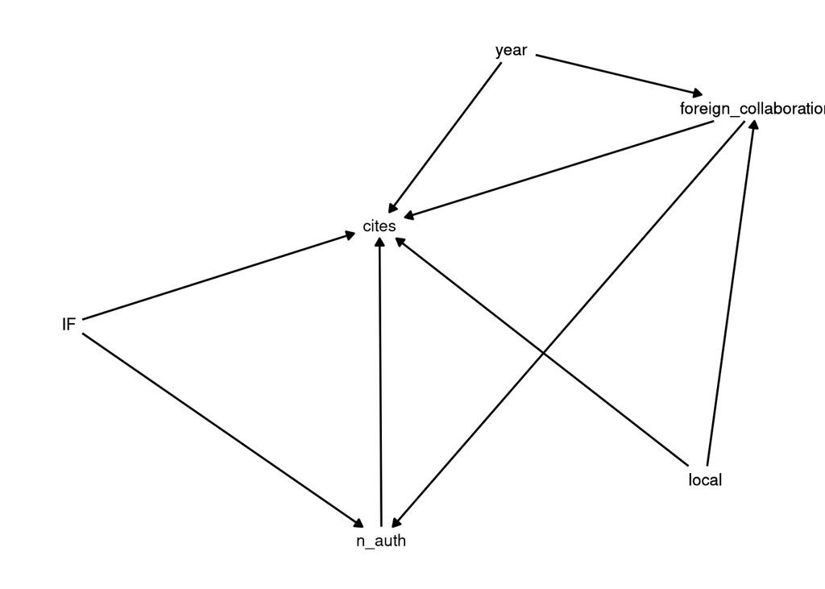

```r
dag = dagitty(
  'dag {
  bb="0,0,1,1"
  IF [exposure,pos="0.283,0.685"]
  cites [outcome,pos="0.448,0.737"]
  foreign_collaboration [pos="0.648,0.799"]
  local [pos="0.621,0.603"]
  n_auth [pos="0.449,0.571"]
  year [exposure,pos="0.518,0.830"]
  IF -> cites
  IF -> n_auth
  foreign_collaboration -> cites
  foreign_collaboration -> n_auth
  local -> cites
  local -> foreign_collaboration
  n_auth -> cites
  year -> cites
  year -> foreign_collaboration
  }
'
)

dag %>%
  ggdag_classic(size = 3.5)+
  theme_void()
```

#### Fit the adjusted models

```r
adjusted_hgm = brm(
  formula = cites ~ year + IF + foreign_collaboration + local + n_auth,
  data = df,
  family = gaussian(),
  file = 'adjusted_hgm'
)
```

Less adjusted model:

```r
less_adjusted_hgm = brm(
  formula = cites ~ year + IF + foreign_collaboration,
  data = df,
  family = gaussian(),
  file = 'less_adjusted_hgm'
)
```

Multilevel model:

```r
multilevel_hgm = brm(
  formula = cites ~ 1 + year + IF + foreign_collaboration + local + n_auth +
    (1 + n_auth |foreign_collaboration + local),
  data = df,
  family = gaussian(),
  # More iterations, because Tail Effective Samples Size (ESS) is too low
  iter = 6000,
  file = 'multilevel_hgm'
)
```

Warning: There were 2006 divergent transitions after warmup :(

Model with cross-level interaction:

```r
cross_hgm = brm(
  formula = cites ~ 1 + year + IF + foreign_collaboration + local + n_auth:foreign_collaboration,
  data = df,
  family = gaussian(),
  # More iterations, because Tail Effective Samples Size (ESS) is too low
  iter = 4000,
  file = 'cross_hgm'
)
```

#### Compare the models

```r
l1 = loo(adjusted_hgm)
l2 = loo(multilevel_hgm)
l3 = loo(cross_hgm)
l4 = loo(less_adjusted_hgm)
loo_compare(l1, l2, l3, l4)
```

```
##                   elpd_diff se_diff
## less_adjusted_hgm  0.0       0.0
## adjusted_hgm      -1.3       1.4
## multilevel_hgm    -1.7       1.5
## cross_hgm         -2.0       1.5
```

There are no significant differences…

#### Plotting conditional effects

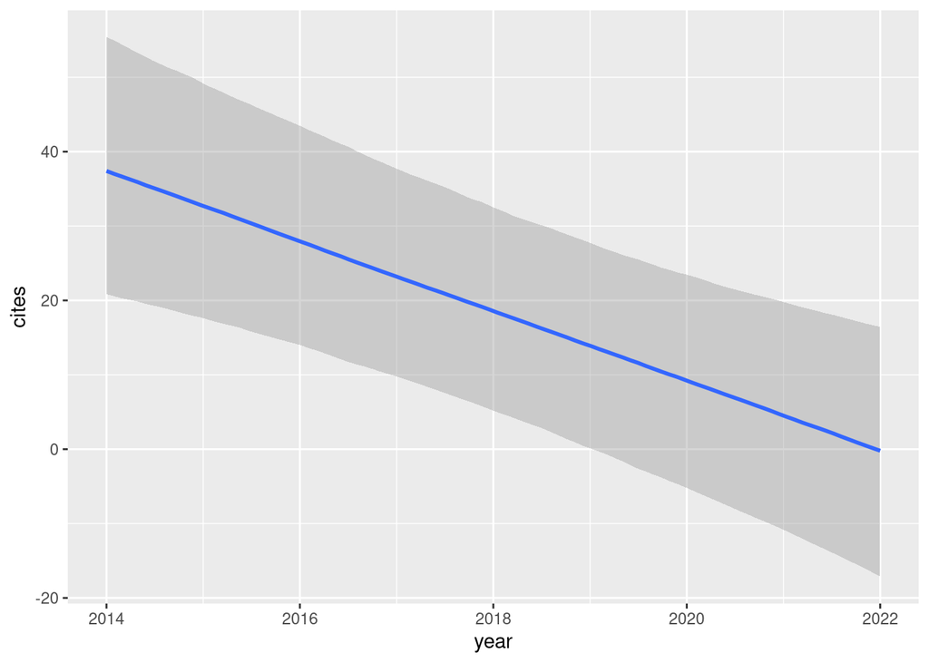

```r
adjusted_hgm %>% conditional_effects(effects = 'year')
```

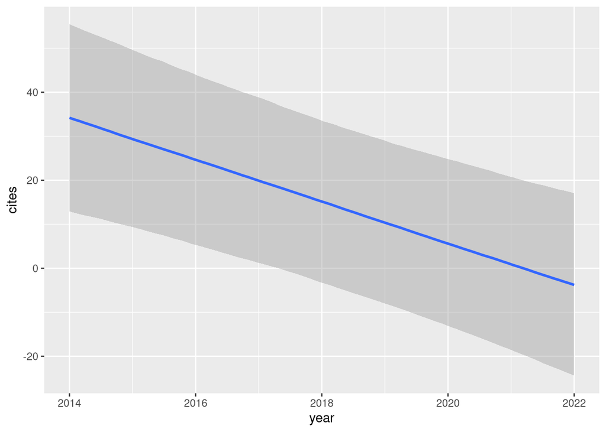

```r
cross_hgm %>% conditional_effects(effects = 'year')
```

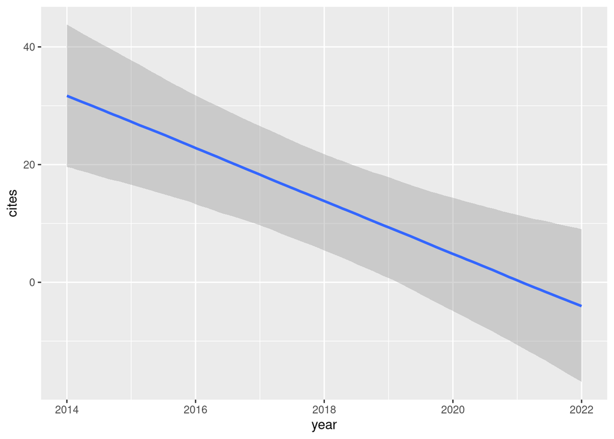

```r
less_adjusted_hgm %>% conditional_effects(effects = 'year')
```

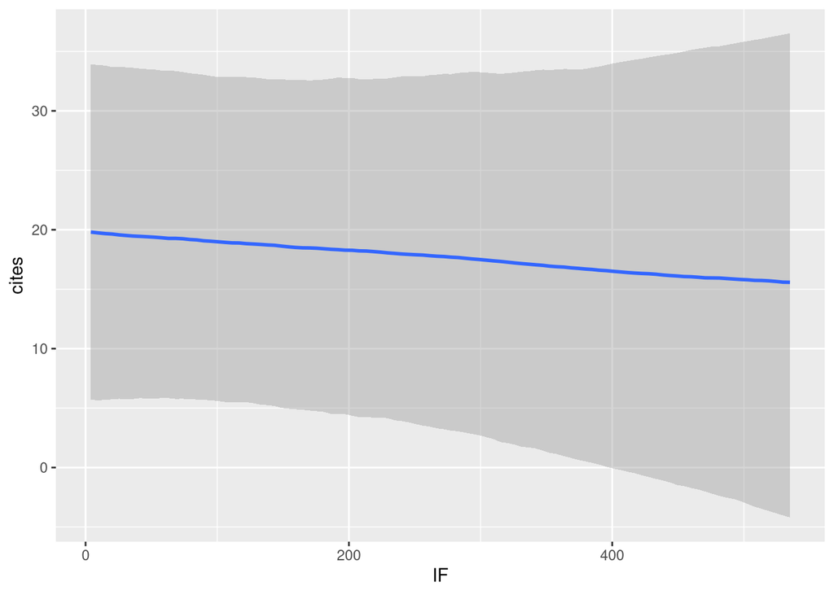

```r
adjusted_hgm %>% conditional_effects(effects = 'IF')
```

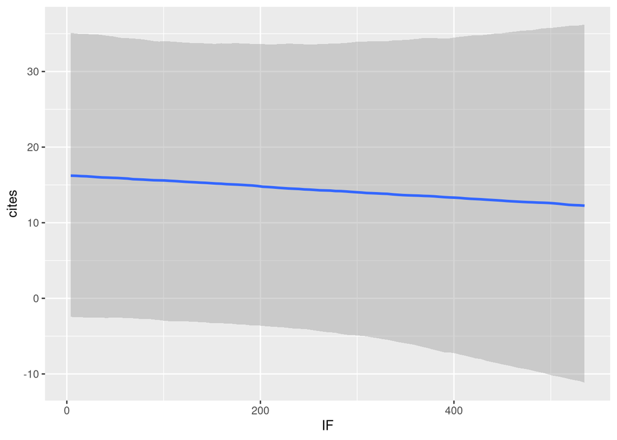

```r
cross_hgm %>% conditional_effects(effects = 'IF')
```

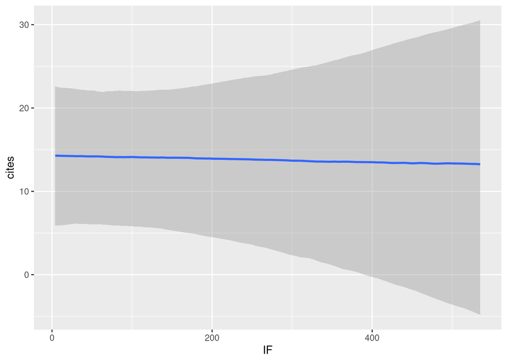

```r
less_adjusted_hgm %>% conditional_effects(effects = 'IF')
```

#### Model summaries

```r
adjusted_hgm
```

```
##  Family: gaussian
##   Links: mu = identity; sigma = identity
## Formula: cites ~ year + IF + foreign_collaboration + local + n_auth
##    Data: df (Number of observations: 67)
##   Draws: 4 chains, each with iter = 2000; warmup = 1000; thin = 1;
##          total post-warmup draws = 4000
##
## Population-Level Effects:
##                          Estimate Est.Error l-95% CI u-95% CI Rhat Bulk_ESS
## Intercept                 9559.90   2489.47  4559.37 14483.84 1.00     4876
## year                        -4.73      1.23    -7.17    -2.25 1.00     4875
## IF                          -0.01      0.02    -0.04     0.03 1.00     5311
## foreign_collaborationyes    12.72      7.43    -2.09    27.19 1.00     3035
## localyes                    -4.15      7.07   -18.12     9.47 1.00     3374
## n_auth                       0.52      0.52    -0.48     1.53 1.00     3929
##                          Tail_ESS
## Intercept                    3011
## year                         2988
## IF                           3049
## foreign_collaborationyes     2766
## localyes                     2395
## n_auth                       2965
##
## Family Specific Parameters:
##       Estimate Est.Error l-95% CI u-95% CI Rhat Bulk_ESS Tail_ESS
## sigma    21.61      1.99    18.16    25.85 1.00     4169     3052
##
## Draws were sampled using sampling(NUTS). For each parameter, Bulk_ESS
## and Tail_ESS are effective sample size measures, and Rhat is the potential
## scale reduction factor on split chains (at convergence, Rhat = 1).
```

```r
cross_hgm
```

```
##  Family: gaussian
##   Links: mu = identity; sigma = identity
## Formula: cites ~ 1 + year + IF + foreign_collaboration + local + n_auth:foreign_collaboration
##    Data: df (Number of observations: 67)
##   Draws: 4 chains, each with iter = 4000; warmup = 2000; thin = 1;
##          total post-warmup draws = 8000
##
## Population-Level Effects:
##                                 Estimate Est.Error l-95% CI u-95% CI Rhat
## Intercept                        9550.05   2553.71  4490.90 14579.25 1.00
## year                               -4.72      1.27    -7.21    -2.22 1.00
## IF                                 -0.01      0.02    -0.04     0.03 1.00
## foreign_collaborationyes            6.44     13.90   -21.40    32.96 1.00
## localyes                           -3.82      7.30   -18.13    10.14 1.00
## foreign_collaborationno:n_auth     -0.36      1.70    -3.66     3.00 1.00
## foreign_collaborationyes:n_auth     0.60      0.55    -0.51     1.70 1.00
##                                 Bulk_ESS Tail_ESS
## Intercept                          11076     6098
## year                               11079     6137
## IF                                 10042     6423
## foreign_collaborationyes            5800     5259
## localyes                            9535     5923
## foreign_collaborationno:n_auth      5978     5312
## foreign_collaborationyes:n_auth     8318     5710
##
## Family Specific Parameters:
##       Estimate Est.Error l-95% CI u-95% CI Rhat Bulk_ESS Tail_ESS
## sigma    21.73      1.96    18.29    26.00 1.00     9017     6199
##
## Draws were sampled using sampling(NUTS). For each parameter, Bulk_ESS
## and Tail_ESS are effective sample size measures, and Rhat is the potential
## scale reduction factor on split chains (at convergence, Rhat = 1).
```

```r
less_adjusted_hgm
```

```
##  Family: gaussian
##   Links: mu = identity; sigma = identity
## Formula: cites ~ year + IF + foreign_collaboration
##    Data: df (Number of observations: 67)
##   Draws: 4 chains, each with iter = 2000; warmup = 1000; thin = 1;
##          total post-warmup draws = 4000
##
## Population-Level Effects:
##                          Estimate Est.Error l-95% CI u-95% CI Rhat Bulk_ESS
## Intercept                 8990.65   2439.21  4182.27 13801.81 1.00     4378
## year                        -4.45      1.21    -6.84    -2.07 1.00     4378
## IF                          -0.00      0.02    -0.04     0.03 1.00     4697
## foreign_collaborationyes    18.10      5.52     7.61    28.85 1.00     4843
##                          Tail_ESS
## Intercept                    3113
## year                         3113
## IF                           3246
## foreign_collaborationyes     3134
##
## Family Specific Parameters:
##       Estimate Est.Error l-95% CI u-95% CI Rhat Bulk_ESS Tail_ESS
## sigma    21.52      1.97    18.09    25.92 1.00     4279     2970
##
## Draws were sampled using sampling(NUTS). For each parameter, Bulk_ESS
## and Tail_ESS are effective sample size measures, and Rhat is the potential
## scale reduction factor on split chains (at convergence, Rhat = 1).
```

# Conclusion

In general, we can say that the models confirm a rather noticeable negative correlation of citations with the year, but the influence of IF could not be identified.